# Multiple Linear Regression

Created on JupyterLab

## Table of Contents

- Prediction
- Class Linear
- Build Custom Modules
- Make Some Data
- Create the Model and Cost Function the PyTorch way
- Train the Model: Batch Gradient Descent

## Preparation

Import the libraries and set the random seed.

```python
# Import the libraries and set the random seed

from torch import nn
import torch
torch.manual_seed(1)
```

```
<torch._C.Generator at 0x7f7b98548cf0>
```

## Prediction

Set weight and bias.

```python
# Set the weight and bias

w = torch.tensor([[2.0], [3.0]], requires_grad=True)
b = torch.tensor([[1.0]], requires_grad=True)
```

Define the parameters. `torch.mm` uses matrix multiplication instead of scaler multiplication.

```python
# Define Prediction Function

def forward(x):
    yhat = torch.mm(x, w) + b
    return yhat
```

The function `forward` implements the following equation:

[figure not shown]

**If we input a *1x2* tensor, because we have a *2x1* tensor as `w`, we will get a *1x1* tensor:**

```python
# Calculate yhat

x = torch.tensor([[1.0, 2.0]])
yhat = forward(x)
print("The result: ", yhat)
```

```
The result:  tensor([[9.]], grad_fn=<AddBackward0>)
```

[figure not shown]

# Each row of the following tensor represents a sample:

```python
# Sample tensor X
# 2D for 2 independent variables

X = torch.tensor([[1.0, 1.0], [1.0, 2.0], [1.0, 3.0]])
```

```python
X.shape
```

```
torch.Size([3, 2])
```

```python
# Make the prediction of X

yhat = forward(X)
print("The result: ", yhat)
```

```
The result:  tensor([[ 6.],
        [ 9.],
        [12.]], grad_fn=<AddBackward0>)
```

## Class Linear

We can use the linear class to make a prediction. You'll also use the linear class to build more complex models.

Let us create a model.

```python
# Make a linear regression model using build-in function
model = nn.Linear(2, 1)
```

Make a prediction with the first sample:

```python
# Make a prediction of x

yhat = model(x)
print("The result: ", yhat)
```

```
The result:  tensor([[-0.3969]], grad_fn=<AddmmBackward0>)
```

Predict with multiple samples `X`:

```python
# Make a prediction of X

yhat = model(X)
print("The result: ", yhat)
```

```
The result:  tensor([[-0.0848],
        [-0.3969],
        [-0.7090]], grad_fn=<AddmmBackward0>)
```

The function performs matrix multiplication as shown in this image:

[figure not shown]

## Build Custom Modules

Now, you'll build a custom module. You can make more complex models by using this method later.

```python
# Create linear_regression Class

class linear_regression(nn.Module):

    # Constructor
    def __init__(self, input_size, output_size):
        super(linear_regression, self).__init__()
        self.linear = nn.Linear(input_size, output_size)

    # Prediction function
    def forward(self, x):
        yhat = self.linear(x)
        return yhat
```

Build a linear regression object. The input feature size is two.

```python
model = linear_regression(2, 1)
```

This will input the following equation:

[figure not shown]

You can see the randomly initialized parameters by using the `parameters()` method:

```python
# Print model parameters

print("The parameters: ", list(model.parameters()))
```

```
The parameters:  [Parameter containing:
tensor([[ 0.3319, -0.6657]], requires_grad=True), Parameter containing:
tensor([0.4241], requires_grad=True)]
```

You can also see the parameters by using the `state_dict()` method:

```python
# Print model parameters

print("The parameters: ", model.state_dict())
```

```
The parameters:  OrderedDict([('linear.weight', tensor([[ 0.3319, -0.6657]])), ('linear.bias', tensor([0.4241]))])
```

Now we input a 1x2 tensor, and we will get a 1x1 tensor.

```python
# Make a prediction of x

yhat = model(x)
print("The result: ", yhat)
```

```
The result:  tensor([[-0.5754]], grad_fn=<AddmmBackward0>)
```

The shape of the output is shown in the following image:

[figure not shown]

Make a prediction for multiple samples:

```python
# Make a prediction of X

yhat = model(X)
print("The result: ", yhat)
```

```
The result:  tensor([[ 0.0903],
        [-0.5754],
        [-1.2411]], grad_fn=<AddmmBackward0>)
```

The shape is shown in the following image:

[figure not shown]

Build a model or object of type `linear_regression`. Using the `linear_regression` object will predict the following tensor:

```python
# Practice: Build a model to predict the follow tensor.
# 2 samples, 4 independent variables
X = torch.tensor([[11.0, 12.0, 13, 14], [11, 12, 13, 14]])

model = linear_regression(4, 1)
yhat = model(X)
print("The result: ", yhat)
```

```
The result:  tensor([[2.1062],
        [2.1062]], grad_fn=<AddmmBackward0>)
```

# Linear Regression Multiple Outputs

## Objective

- How to create a complicated models using pytorch build in functions.

## Preparation

We'll need the following libraries:

```python
# Libraries

from torch import nn,optim
import torch
import numpy as np
import matplotlib.pyplot as plt

from mpl_toolkits.mplot3d import Axes3D
from torch.utils.data import Dataset, DataLoader
```

Set the random seed:

```python
# Set the random seed to 1.

torch.manual_seed(1)
```

```
<torch._C.Generator at 0x7f7b98548cf0>
```

Use this function for plotting:

```python
# The function for plotting 2D

def Plot_2D_Plane(model, dataset, n=0):
    w1 = model.state_dict()['linear.weight'].numpy()[0][0]
    w2 = model.state_dict()['linear.weight'].numpy()[0][1]
    b = model.state_dict()['linear.bias'].numpy()

    # Data
    x1 = data_set.x[:, 0].view(-1, 1).numpy()
    x2 = data_set.x[:, 1].view(-1, 1).numpy()
    y = data_set.y.numpy()

    # Make plane
    X, Y = np.meshgrid(np.arange(x1.min(), x1.max(), 0.05), np.arange(x2.min(), x2.max(), 0.05))
    yhat = w1 * X + w2 * Y + b

    # Plotting
    fig = plt.figure()
    ax = fig.gca(projection='3d')

    ax.plot(x1[:, 0], x2[:, 0], y[:, 0],'ro', label='y') # Scatter plot

    ax.plot_surface(X, Y, yhat) # Plane plot

    ax.set_xlabel('x1 ')
    ax.set_ylabel('x2 ')
    ax.set_zlabel('y')
    plt.title('estimated plane iteration:' + str(n))
    ax.legend()

    plt.show()
```

## Make Some Data

Create a dataset class with two-dimensional features:

```python
# Create a 2D dataset

class Data2D(Dataset):

    # Constructor
    def __init__(self):
        self.x = torch.zeros(20, 2)
        self.x[:, 0] = torch.arange(-1, 1, 0.1)
        self.x[:, 1] = torch.arange(-1, 1, 0.1)
        self.w = torch.tensor([[1.0], [1.0]])
        self.b = 1
        self.f = torch.mm(self.x, self.w) + self.b
        self.y = self.f + 0.1 * torch.randn((self.x.shape[0],1))
        self.len = self.x.shape[0]

    # Getter
    def __getitem__(self, index):
        return self.x[index], self.y[index]

    # Get Length
    def __len__(self):
        return self.len
```

Create a dataset object:

```python
# Create the dataset object
data_set = Data2D()
```

## Create the Model, Optimizer, and Total Loss Function (Cost)

Create a customized linear regression module:

```python
# Create a customized linear

class linear_regression(nn.Module):

    # Constructor
    def __init__(self, input_size, output_size):
        super(linear_regression, self).__init__()
        self.linear = nn.Linear(input_size, output_size)

    # Prediction
    def forward(self, x):
        yhat = self.linear(x)
        return yhat
```

Create a model. Use two features: make the input size 2 and the output size 1:

```python
# Create the linear regression model and print the parameters

model = linear_regression(2,1)
print("The parameters: ", list(model.parameters()))
```

```
The parameters:  [Parameter containing:
tensor([[ 0.6209, -0.1178]], requires_grad=True), Parameter containing:
tensor([0.3026], requires_grad=True)]
```

Create an optimizer object. Set the learning rate to 0.1. **Don't forget to enter the model parameters in the constructor.**

```python
# Create the optimizer

optimizer = optim.SGD(model.parameters(), lr=0.1)
```

Create the criterion function that calculates the total loss or cost:

```python
# Create the cost function

criterion = nn.MSELoss()
```

Create a data loader object. Set the batch_size equal to 2:

```python
# Create the data loader

train_loader = DataLoader(dataset=data_set, batch_size=2)
```

## Train the Model via Mini-Batch Gradient Descent

Run 100 epochs of Mini-Batch Gradient Descent and store the total loss or cost for every iteration. Remember that this is an approximation of the true total loss or cost:

```
Before Training:
```

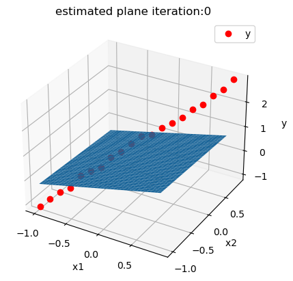

```
After Training:
```

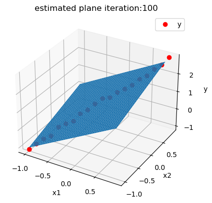

```python
# Train the model

LOSS = []
print("Before Training: ")
Plot_2D_Plane(model, data_set)
epochs = 100

def train_model(epochs):
    for epoch in range(epochs):
        for x,y in train_loader:
            #make a prediction
            yhat=model(x)
            #calculate the loss
            loss=criterion(yhat,y)
            #store loss/cost
            LOSS.append(loss.item())
            #clear gradient
            optimizer.zero_grad()
            #Backward pass: compute gradient of the loss with respect to all the learnable parameters
            loss.backward()
            #the step function on an Optimizer makes an update to its parameters
            optimizer.step()

train_model(epochs)
print("After Training: ")
Plot_2D_Plane(model, data_set, epochs)
```

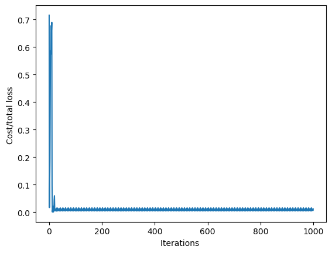

```python
# Plot out the Loss and iteration diagram

plt.plot(LOSS)
plt.xlabel("Iterations ")
plt.ylabel("Cost/total loss ")
```

Create a new `model1`. Train the model with a batch size 30 and learning rate 0.1, store the loss or total cost in a list `LOSS1`, and plot the results.

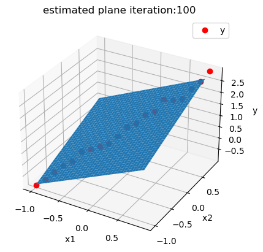

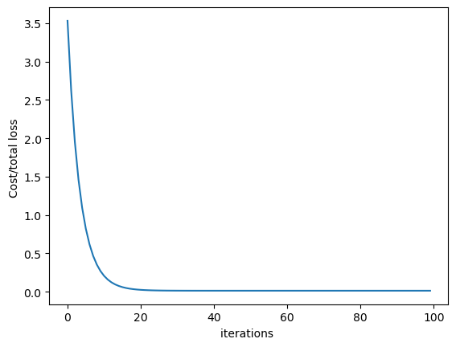

```python
# Practice create model1. Train the model with batch size 30 and learning rate 0.1, store the loss in a list <code>LOSS1</code>. Plot the results.

data_set = Data2D()

train_loader = DataLoader(dataset = data_set, batch_size = 30)
model1 = linear_regression(2, 1)
optimizer = optim.SGD(model1.parameters(), lr = 0.1)
LOSS1 = []
epochs = 100
def train_model(epochs):
    for epoch in range(epochs):
        for x,y in train_loader:
            yhat = model1(x)
            loss = criterion(yhat,y)
            LOSS1.append(loss.item())
            optimizer.zero_grad()
            loss.backward()
            optimizer.step()
train_model(epochs)
Plot_2D_Plane(model1 , data_set, epochs)
plt.plot(LOSS1)
plt.xlabel("iterations ")
plt.ylabel("Cost/total loss ")
```

Use the following validation data to calculate the total loss or cost for both models:

```python
torch.manual_seed(2)

validation_data = Data2D()
Y = validation_data.y
X = validation_data.x

print("total loss or cost for model: ",criterion(model(X),Y))
print("total loss or cost for model: ",criterion(model1(X),Y))
```

```
total loss or cost for model:  tensor(0.0081, grad_fn=<MseLossBackward0>)
total loss or cost for model:  tensor(0.0108, grad_fn=<MseLossBackward0>)
```

# Authors' rights

Machine Learning with Python course by IBM on Coursera: https://www.coursera.org/learn/machine-learning-with-python/

Completed and modified by Mathilde Marie Duville as part of the IBM Artificial Intelligence Engineering Professional Certificate and corresponding IBM badges. Please, follow the subsequent links to confirm the accreditation:

https://www.coursera.org/account/accomplishments/professional-cert/KSLW773DAATP?utm_source=link&utm_medium=certificate&utm_content=cert_image&utm_campaign=sharing_cta&utm_product=prof

https://www.credly.com/users/mathilde-marie-duville/badges

Author: [Joseph Santarcangelo](https://www.linkedin.com/in/joseph-s-50398b136/) has a PhD in Electrical Engineering, his research focused on using machine learning, signal processing, and computer vision to determine how videos impact human cognition. Joseph has been working for IBM since he completed his PhD.

Other contributors: [Michelle Carey](https://www.linkedin.com/in/michelleccarey/), Mavis Zhou